# 05. Repeat Purchase Classification

**Mục tiêu:**

- Dự đoán khách hàng có mua lại trong 90 ngày (`repeat_purchase_90d`).
- So sánh ít nhất 4 thuật toán: DummyClassifier (baseline), Logistic Regression, Decision Tree, Random Forest.
- **Chọn model bằng Cross-Validation trên tập huấn luyện** (KHÔNG dùng test set để chọn model).
- Test set chỉ được dùng cho đánh giá cuối cùng duy nhất một lần.
- Pipeline preprocessing + model có thể tái sử dụng cho Dashboard Streamlit.

```python
import sys, os
sys.path.insert(0, os.path.abspath('..'))
import pandas as pd
import numpy as np
import warnings
warnings.filterwarnings("ignore")

from src.config import (
    PROCESSED_DIR, FIGURES_CLASSIFICATION, TABLES_CLASSIFICATION,
    MODELS_CLASSIFICATION_DIR, RANDOM_STATE, TEST_SIZE, REPEAT_PURCHASE_WINDOW_DAYS
)
from src.classification import (
    validate_classification_dataset, split_classification_data,
    build_preprocessor, build_model_pipelines, cross_validate_models,
    select_best_model, train_final_models, evaluate_on_test,
    get_feature_importance, save_classification_artifacts
)
from src.evaluation import (
    plot_confusion_matrix, plot_roc_curves, plot_precision_recall_curves,
    plot_model_comparison, plot_feature_importance, save_classification_report_csv
)

TARGET_COL = 'repeat_purchase_90d'

%matplotlib inline
```

## 1. Tải và Kiểm tra Dữ liệu

Dữ liệu đầu vào là `repeat_purchase_features.csv` đã được tạo ở bước Feature Engineering (03).  
Kiểm tra chống data leakage: không có `future_invoice_count`, `future_revenue`, không duplicate.

```python
df = pd.read_csv(PROCESSED_DIR / 'repeat_purchase_features.csv')
print(f"Customers: {len(df):,} | Columns: {df.shape[1]}")

checks = validate_classification_dataset(df, TARGET_COL)
for c in checks:
    print(c)

# Class distribution
class_counts = df[TARGET_COL].value_counts().sort_index()
print(f"\nClass Balance:")
print(f"  0 (No Repeat): {class_counts[0]:,} ({class_counts[0]/len(df)*100:.1f}%)")
print(f"  1 (Repeat):    {class_counts[1]:,} ({class_counts[1]/len(df)*100:.1f}%)")
```

```
Customers: 3,368 | Columns: 13
[PASS] Target 'repeat_purchase_90d' exists
[PASS] Target only contains 0/1
[PASS] No missing target values
[PASS] No duplicate CustomerID (3368 unique)
[PASS] No future columns (leakage check)
[PASS] Both classes present: {1: np.int64(1919), 0: np.int64(1449)}

Class Balance:
  0 (No Repeat): 1,449 (43.0%)
  1 (Repeat):    1,919 (57.0%)
```

## 2. Train/Test Split & Preprocessing Pipeline

- Chia dữ liệu theo `stratify=y` để giữ tỷ lệ class.
- `ColumnTransformer` xử lý numeric (Impute + Scale) và categorical (Impute + OneHotEncode).
- **Pipeline preprocessing được gắn liền với model** để tái sử dụng cho Dashboard.

```python
X_train, X_test, y_train, y_test = split_classification_data(df, TARGET_COL)
print(f"Train: {len(X_train):,} | Test: {len(X_test):,}")

preprocessor, numeric_features, categorical_features = build_preprocessor(X_train)
print(f"Numeric features: {numeric_features}")
print(f"Categorical features: {categorical_features}")

model_pipelines = build_model_pipelines(preprocessor)
print(f"\nModels to compare: {list(model_pipelines.keys())}")
```

```
Train: 2,694 | Test: 674
Numeric features: ['Recency', 'Frequency', 'Monetary', 'TotalItems', 'UniqueProducts', 'ActiveDays', 'AverageOrderValue', 'AverageItemsPerInvoice', 'CustomerLifetimeDays']
Categorical features: ['Country']

Models to compare: ['DummyClassifier', 'LogisticRegression', 'DecisionTree', 'RandomForest']
```

## 3. Cross-Validation (Chọn Model)

> **QUAN TRỌNG**: Model được chọn hoàn toàn dựa trên kết quả Cross-Validation trên tập huấn luyện.  
> Test set CHƯA được sử dụng ở bước này.

```python
cv_results = cross_validate_models(model_pipelines, X_train, y_train)
display(cv_results.sort_values('cv_f1_mean', ascending=False))

selected_model = select_best_model(cv_results)
print(f"\n>>> Model được chọn (bằng CV): {selected_model}")
print(f">>> Test set CHƯA được dùng để chọn model.")
```

|  | model | cv_f1_mean | cv_f1_std | cv_roc_auc_mean | cv_roc_auc_std | cv_average_precision_mean | cv_average_precision_std | cv_runtime_seconds |
| --- | --- | --- | --- | --- | --- | --- | --- | --- |
| 0 | DummyClassifier | 0.725940 | 0.000344 | 0.500000 | 0.000000 | 0.569785 | 0.000423 | 3.28 |
| 3 | RandomForest | 0.672584 | 0.019140 | 0.699079 | 0.013734 | 0.784951 | 0.013322 | 2.52 |
| 1 | LogisticRegression | 0.664984 | 0.014968 | 0.732265 | 0.018326 | 0.801027 | 0.013208 | 5.80 |
| 2 | DecisionTree | 0.650245 | 0.016162 | 0.637491 | 0.019611 | 0.681687 | 0.021032 | 4.26 |

```
>>> Model được chọn (bằng CV): RandomForest
>>> Test set CHƯA được dùng để chọn model.
```

## 4. Huấn luyện & Đánh giá cuối cùng trên Test Set

Sau khi chọn model bằng CV, huấn luyện tất cả model trên toàn bộ tập training.  
Đánh giá trên test set **chỉ một lần duy nhất** (không tuning thêm).

```python
trained_pipelines = train_final_models(model_pipelines, X_train, y_train)
comparison_df = evaluate_on_test(trained_pipelines, X_test, y_test, cv_results, selected_model)
display(comparison_df[['model', 'cv_f1_mean', 'test_f1', 'test_roc_auc', 'test_precision', 'test_recall', 'selected']])
```

|  | model | cv_f1_mean | test_f1 | test_roc_auc | test_precision | test_recall | selected |
| --- | --- | --- | --- | --- | --- | --- | --- |
| 0 | DummyClassifier | 0.7259 | 0.7259 | 0.5000 | 0.5697 | 1.0000 | False |
| 1 | LogisticRegression | 0.6650 | 0.7043 | 0.7763 | 0.7941 | 0.6328 | False |
| 2 | DecisionTree | 0.6502 | 0.6848 | 0.6828 | 0.7159 | 0.6562 | False |
| 3 | RandomForest | 0.6726 | 0.7086 | 0.7438 | 0.7280 | 0.6901 | True |

## 5. Trực quan hóa

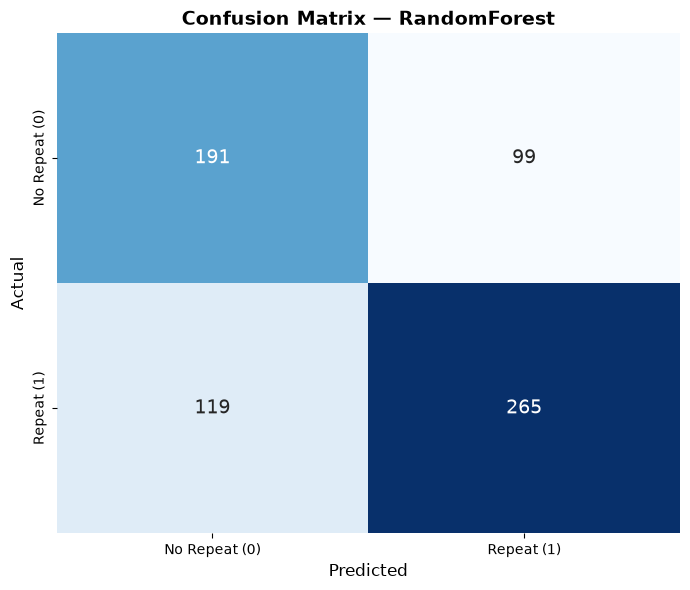

```python
best_pipeline = trained_pipelines[selected_model]
y_pred_best = best_pipeline.predict(X_test)

plot_confusion_matrix(y_test, y_pred_best, selected_model)
```

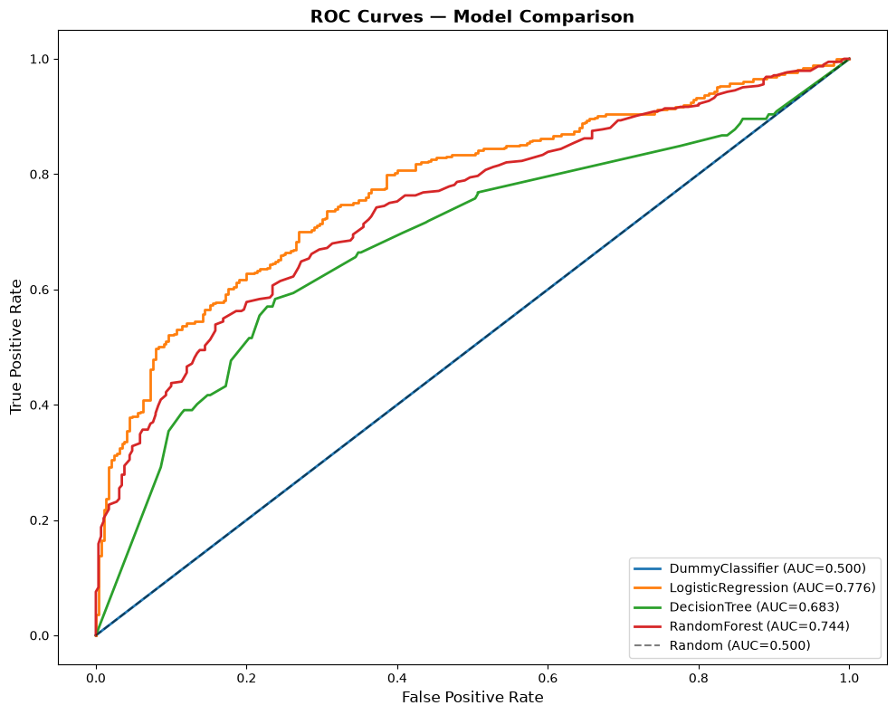

```python
plot_roc_curves(trained_pipelines, X_test, y_test)
```

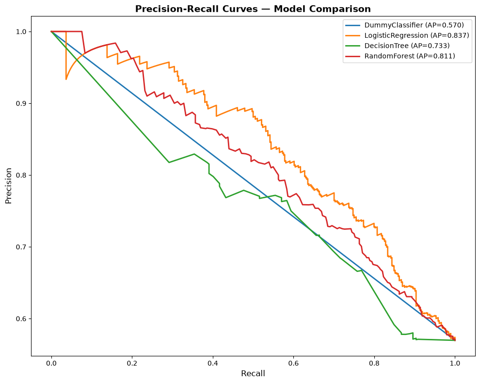

```python
plot_precision_recall_curves(trained_pipelines, X_test, y_test)
```

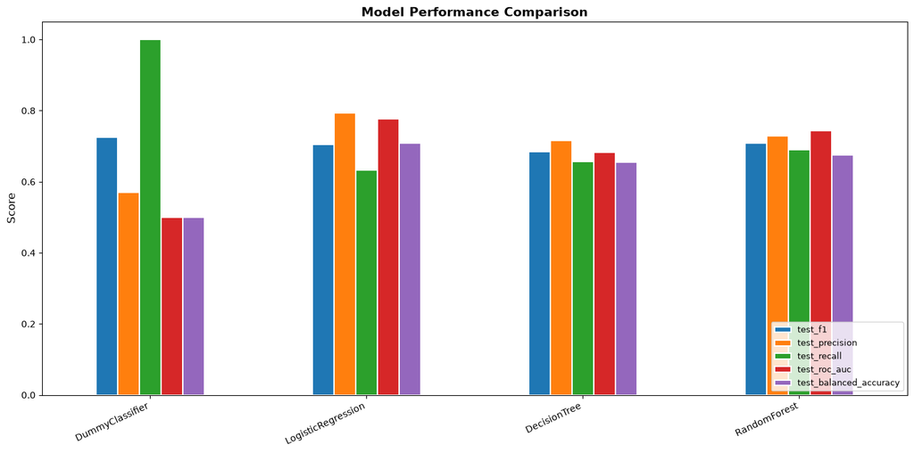

```python
plot_model_comparison(comparison_df)
```

## 6. Feature Importance

|  | feature | importance |
| --- | --- | --- |
| 0 | Recency | 0.139253 |
| 1 | Monetary | 0.136043 |
| 2 | UniqueProducts | 0.129772 |
| 3 | TotalItems | 0.127866 |
| 4 | AverageOrderValue | 0.123478 |
| 5 | AverageItemsPerInvoice | 0.117268 |
| 6 | CustomerLifetimeDays | 0.081577 |
| 7 | Frequency | 0.057643 |
| 8 | ActiveDays | 0.056645 |
| 9 | Country_United Kingdom | 0.007406 |
| 10 | Country_Germany | 0.004079 |
| 11 | Country_France | 0.003214 |
| 12 | Country_Spain | 0.001761 |
| 13 | Country_Belgium | 0.001720 |
| 14 | Country_Switzerland | 0.001583 |

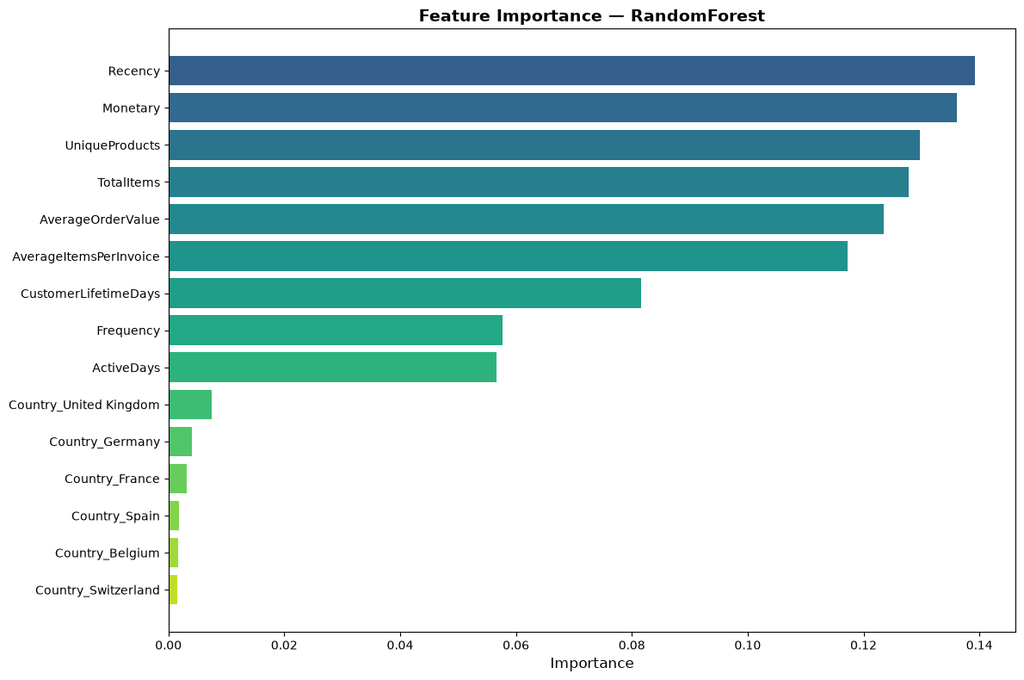

```python
fi_df = get_feature_importance(best_pipeline, numeric_features + categorical_features)
display(fi_df.head(15))
plot_feature_importance(fi_df, selected_model)
```

## 7. Lưu kết quả

```python
# Save tables
comparison_df.to_csv(TABLES_CLASSIFICATION / 'model_comparison.csv', index=False)
cv_results.to_csv(TABLES_CLASSIFICATION / 'cv_results.csv', index=False)
fi_df.to_csv(TABLES_CLASSIFICATION / 'feature_importance.csv', index=False)

save_classification_report_csv(y_test, y_pred_best, TABLES_CLASSIFICATION / 'classification_report.csv')

try:
    y_proba_best = best_pipeline.predict_proba(X_test)[:, 1]
except:
    y_proba_best = np.full(len(y_pred_best), np.nan)

pred_df = X_test.copy()
if 'CustomerID' in df.columns:
    pred_df.insert(0, 'CustomerID', df.loc[X_test.index, 'CustomerID'].values)
pred_df[TARGET_COL + '_actual'] = y_test.values
pred_df[TARGET_COL + '_predicted'] = y_pred_best
pred_df[TARGET_COL + '_probability'] = y_proba_best
pred_df.to_csv(TABLES_CLASSIFICATION / 'test_predictions.csv', index=False)

summary = {
    'total_customers': len(df), 'class_0': int((df[TARGET_COL]==0).sum()),
    'class_1': int((df[TARGET_COL]==1).sum()), 'random_state': RANDOM_STATE, 'test_size': TEST_SIZE,
}
pd.DataFrame([summary]).to_csv(TABLES_CLASSIFICATION / 'classification_data_summary.csv', index=False)

# Save models
import json
metadata = {
    'target_col': TARGET_COL, 'feature_columns': list(X_train.columns),
    'numeric_features': numeric_features, 'categorical_features': categorical_features,
    'random_state': RANDOM_STATE, 'test_size': TEST_SIZE, 'selected_model': selected_model,
    'selection_metric': 'cv_f1_mean', 'threshold': 0.5,
    'training_row_count': len(X_train), 'test_row_count': len(X_test),
    'window_days': REPEAT_PURCHASE_WINDOW_DAYS, 'class_weight': 'balanced',
}
save_classification_artifacts(trained_pipelines, selected_model, metadata,
                              MODELS_CLASSIFICATION_DIR, TABLES_CLASSIFICATION, fi_df)
print("All outputs saved successfully.")
```

```
All outputs saved successfully.
```